# Checking

# Ensemble Learning

## 1

1. n_estmators parameter specifies number of trees. Increasing the number of trees generally improves the performance of the algorithm, but also increases the computation time.
2. criterion: This parameter specifies the function used to measure the quality of a split in the decision tree.
3. max_depth specifies the maximum depth of each decision tree.

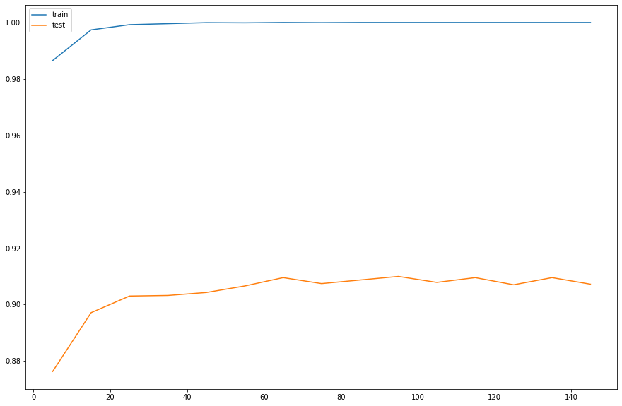

```
max train accuracy for n=65 and acc=0.9999406739439962
max test accuracy for n=95 and acc=0.9099894847528917
```

```python
from sklearn.ensemble import RandomForestClassifier
n_estimators = np.arange(5, 150, 10)
train_acc = []
test_acc = []
for ni in n_estimators:
    rfc = RandomForestClassifier(n_estimators=ni, criterion='entropy')
    rfc.fit(X_train, y_train)
    y_pred_test = rfc.predict(X_test)
    y_pred_train = rfc.predict(X_train)
    test_acc.append(np.mean(y_pred_test == y_test))
    train_acc.append(np.mean(y_pred_train == y_train))
plt.figure(figsize=(15,10))
plt.plot(n_estimators, train_acc, label='train')
plt.plot(n_estimators, test_acc, label='test')
plt.legend()
plt.show()
print(f'max train accuracy for n={n_estimators[np.argmax(train_acc)]} and acc={np.max(train_acc)}')
print(f'max test accuracy for n={n_estimators[np.argmax(test_acc)]} and acc={np.max(test_acc)}')
```

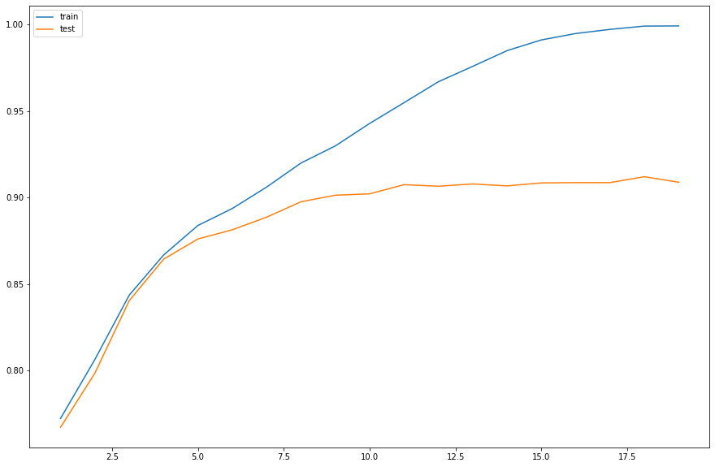

```
max train accuracy for n=19 and acc=0.9993
max test accuracy for n=18 and acc=0.9121
```

```python
max_depth = np.arange(1, 20)
train_acc = []
test_acc = []
for mi in max_depth:
    rfc = RandomForestClassifier(max_depth=mi, criterion='entropy')
    rfc.fit(X_train, y_train)
    y_pred_test = rfc.predict(X_test)
    y_pred_train = rfc.predict(X_train)
    test_acc.append(np.mean(y_pred_test == y_test).round(4))
    train_acc.append(np.mean(y_pred_train == y_train).round(4))
plt.figure(figsize=(15,10))
plt.plot(max_depth, train_acc, label='train')
plt.plot(max_depth, test_acc, label='test')
plt.legend()
plt.show()
print(f'max train accuracy for n={max_depth[np.argmax(train_acc)]} and acc={np.max(train_acc)}')
print(f'max test accuracy for n={max_depth[np.argmax(test_acc)]} and acc={np.max(test_acc)}')
```

```python
rfc = RandomForestClassifier()

parameters = {
    'n_estimators': np.arange(20, 220, 40),
    'criterion': ['gini', 'entropy'],
    'max_depth': np.arange(2, 12, 2),
}
clf = GridSearchCV(
    estimator=rfc,
    param_grid=parameters,
    scoring='accuracy',
    cv=10,
    verbose=True
)
clf.fit(X_train, y_train)
print("Tuned Hyperparameters :", clf.best_params_)
print("Accuracy :",clf.best_score_)
```

```
Fitting 10 folds for each of 50 candidates, totalling 500 fits
Tuned Hyperparameters : {'criterion': 'gini', 'max_depth': 10, 'n_estimators': 180}
Accuracy : 0.9029434582580933
```

```
train accuracy=0.9466658756525866
              precision    recall  f1-score   support

           0       0.91      0.90      0.90      2365
           1       0.90      0.91      0.91      2390

    accuracy                           0.90      4755
   macro avg       0.90      0.90      0.90      4755
weighted avg       0.90      0.90      0.90      4755
```

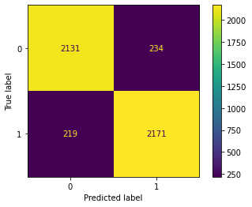

```python
rfc = RandomForestClassifier(n_estimators=100, criterion='gini', max_depth=10)
rfc.fit(X_train,y_train)
y_pred = rfc.predict(X_test)
cm = confusion_matrix(y_test, y_pred)
disp = ConfusionMatrixDisplay(confusion_matrix=cm, display_labels=clf.classes_)
disp.plot()
print(f'train accuracy={np.mean(y_train == rfc.predict(X_train))}')
print(classification_report(y_test, y_pred))
```

# gradient-boosting

XGBoost is normally used to train gradient-boosted decision trees and other gradient boosted models. Random Forests use the same model representation and inference, as gradient-boosted decision trees, but a different training algorithm so XGBoost is ensemble learning algorithm which train more than one trees. it hase some differences in traning step and combining results with random forests.

```python
from xgboost import XGBClassifier
xgb = XGBClassifier()

parameters = {
    'max_depth': np.arange(2, 10, 1),
    'n_estimators': np.arange(20, 220, 40),
    'learning_rate': [1, 0.1, 0.01, 0.05]
}
parameters = {
    'n_estimators': np.arange(20, 220, 40),
    'criterion': ['gini', 'entropy'],
    'max_depth': np.arange(2, 12, 2),
}
clf = GridSearchCV(
    estimator=xgb,
    param_grid=parameters,
    scoring='accuracy',
    cv=10
)
clf.fit(X_train, y_train)
print("Tuned Hyperparameters :", clf.best_params_)
print("Accuracy :",clf.best_score_)
```

[output not shown]

```
train accuracy=0.9345040341718083
              precision    recall  f1-score   support

           0       0.92      0.90      0.91      2365
           1       0.91      0.92      0.91      2390

    accuracy                           0.91      4755
   macro avg       0.91      0.91      0.91      4755
weighted avg       0.91      0.91      0.91      4755
```

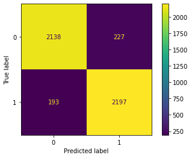

```python
xgb = XGBClassifier(n_estimators=180, max_depth=4, learning_rate=0.1)
xgb.fit(X_train,y_train)
y_pred = xgb.predict(X_test)
cm = confusion_matrix(y_test, y_pred)
disp = ConfusionMatrixDisplay(confusion_matrix=cm, display_labels=clf.classes_)
disp.plot()
print(f'train accuracy={np.mean(y_train == xgb.predict(X_train))}')
print(classification_report(y_test, y_pred))
```